# Part II - What loan characteristics are associated with a high number of investors?

## by Harnex Kakandelwa

## Investigation Overview

My goal was to find out what loan characteristics are associated with a high number of investors. For this, I looked at how the association between risk level and investors was influenced by other variables (which included loan term, employment status and borrower type). I also looked at the interaction between investors and the estimated return and loan amount.

In terms of the findings, the data seemed to support the proposition that relatively low interest rates could signify low risk thus making such loans more attractive to investors. Delving deep into this, the data seemed to suggest that loans associated with borrowers that can be classified as low risk were indeed likely to be funded by investors regardless of the other variables considered. The results also suggested that loan amount has an influence on the level of estimated return at which lenders are more likely to fund a loan.

## Dataset Overview

The dataset coverered over 100,000 loans with information related to the listing, loan amount, number of investors, interest rate, current loan status, borrower's employment status, income and so on. For the final analysis, data points with unverifiable income and extremely large stated monthly income values were removed from the dataset.

## Distribution of the number of investors

The distribution of the number of investors is long-tailed. For most of the loans, the number of investors is from 1 to 100. Only in a few cases, do we have more than 500 investors funding a loan. In extremely few cases, we have more than 900 investors.

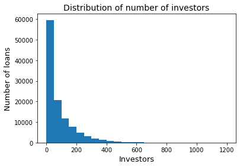

## Relationship between the number of investors and interest rate

Although there is no clear relationship between interest rate and the number of investors, its actually unusual that loans with high interest rates, for example, close to 50% are associated with very few investors while loans with interest rates between 10% and 25% seem to be associated with a very high number of investors. Could it be that low interest rates signify low risk and therefore more attractive to investors?

To see this clearly, let's check if there is a relationship between interest rate and risk level.

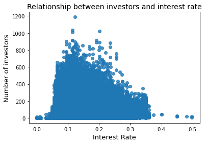

### Risk Level and Interest Rate

The data seems to suggest that indeed most of the loans that are associated with borrowers that are in the low risk category have lower interest rates than loans for moderate and high risk borrowers. Even in terms of the median, loans associated with borrowers in the high risk category have the highest median interest rate while loans for low risk borrowers have the lowest. This could explain why loans with relatively low interest rates seem to be associated with a high number of investors. Perhaps most investors are risk averse?

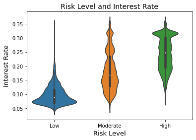

### How is the association between risk level and investors influenced by other variables?

#### Investors, Risk Level and Loan Term

Across all loan terms, loans associated with borrowers who can be categorized as low risk have the highest median number of investors followed by loans for moderate risk borrowers. For loans associated with moderate and high risk borrowers, the median number of investors seems to be decreasing as the loan term increases. This suggests that investors are less likely to fund loans associated with risky borrowers if the term is long, for example, 36 months or more.

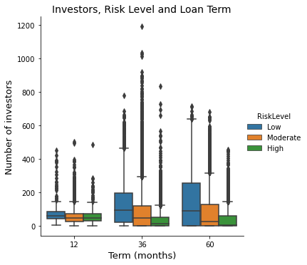

#### Investors, Risk Level and Borrower Type

Loans associated with low risk borrowers have a similar median number of investors for both old and new borrowers. This seems to suggest that borrowers who are categorized as low risk are more likely to have their loans funded regardless of whether they are getting a loan for the first time or not.

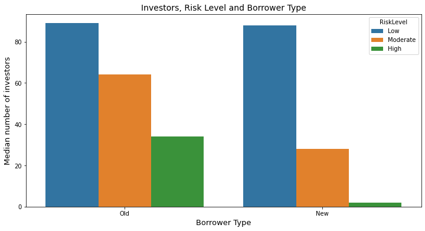

#### Investors, Risk Level and Employment Status

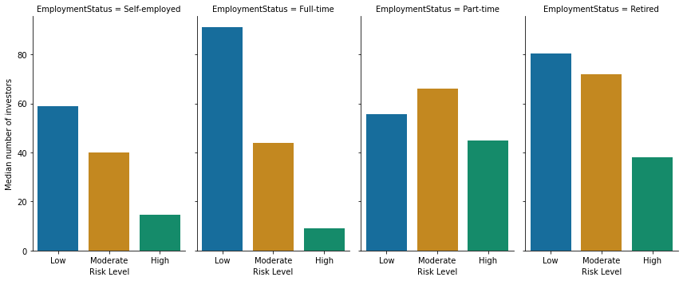